# Big Data Analytics Coursework 1

Lucie Burgess 13109772

Wednesday 26 October, 2016

## Q1 - basic statistics

#### A. Suppose you ask a group of 10 students at Birkbeck College how many siblings they have. The number obtained are as follows: 2,3,0,5,2,1,1,0,3,3

```r
x <- c(2,3,0,5,2,1,1,0,3,3)
sort(x)
```

```
##  [1] 0 0 1 1 2 2 3 3 3 5
```

```r
table(x)
```

```
## x
## 0 1 2 3 5
## 2 2 2 3 1
```

#### Find the following measures of central tendency:

##### (i) the mean

```r
mean(x)
```

```
## [1] 2
```

```r
cat("The mean of x is",mean(x))
```

```
## The mean of x is 2
```

##### (ii) the median

```r
median(x)
```

```
## [1] 2
```

```r
cat("The median of x is",median(x))
```

```
## The median of x is 2
```

##### (iii) the mode

```r
mode <- function(x) {
    if (is.numeric(x)) {
        x_table <- table(x)
        return(as.numeric(names(x_table)[which.max(x_table)]))
    }
}
cat("The mode of x is",mode(x))
```

```
## The mode of x is 3
```

#### Find the following measures of variation:

##### (v) the standard deviation

```r
var(x)
```

```
## [1] 2.444444
```

```r
cat("The variance of x is",var(x))
```

```
## The variance of x is 2.444444
```

```r
sd(x)
```

```
## [1] 1.563472
```

```r
cat("The variance of y is",var(x))
```

```
## The variance of y is 2.444444
```

#### B. Suppose the 10 students have the following ages: 23 25 18 45 30 21 22 19 29 35

```r
y <- c(23,25,18,45,30,21,22,19,29,35)
```

##### b(i) Find the covariance and the correlation between the number of siblings and the age of the students.

```r
cov(x,y)
```

```
## [1] 11.88889
```

```r
cor(x,y)
```

```
## [1] 0.9116971
```

##### b(ii) What is the correlation between the number of siblings and the age of the students?

There is a positive correlation between the number of siblings and their age.

##### b(iii) Is there a causal relationship between the two? Explain your answer.

There is a strong positive correlation (over 0.9, maximum possible is 1.0) between the age of the students and the number of siblings. However, I think that there is no causation between the two.  
I don’t know what’s causing the correlation in this particular group - it could be related to modern advances in contraception, or social attitudes - for example, if you were born in the 1970s perhaps families tended to be larger than they are today. However, there is not a causal relationship: the number of siblings is determined by the parents of the students, not the students themselves!

## Q2 Getting familiar with R

##### (a) Load the Boston data set and find out what it represents.

```r
library(MASS)
?Boston
names(Boston)
```

```
##  [1] "crim"    "zn"      "indus"   "chas"    "nox"     "rm"      "age"
##  [8] "dis"     "rad"     "tax"     "ptratio" "black"   "lstat"   "medv"
```

Running this command results in a documentation file being shown, which demonstrates that the Boston data frame has 506 rows and 14 columns. The data represents housing values in suburbs of Boston, Massachusetts, incluindg per capita crime rate by town, proportion of non-retail business acres per town, etc.  
The rows are suburbs (with predictors/observations for every suburb). The columns contain values, observations for each suburb.

##### (b) Make some pairwise scatterplots of the predictors (columns) in this data set. Describe your findings.

e.g. scatter plot of residential land zoned for lots >25,000 sqft (zn, variable x) against per capita crime rate by town (crim, variable y)  
Findings: crim and zn are not obviously related. There is no obvious increase in the crime rate with the change in zoned residential land predictor. Low correlation between predictors zn and crim.

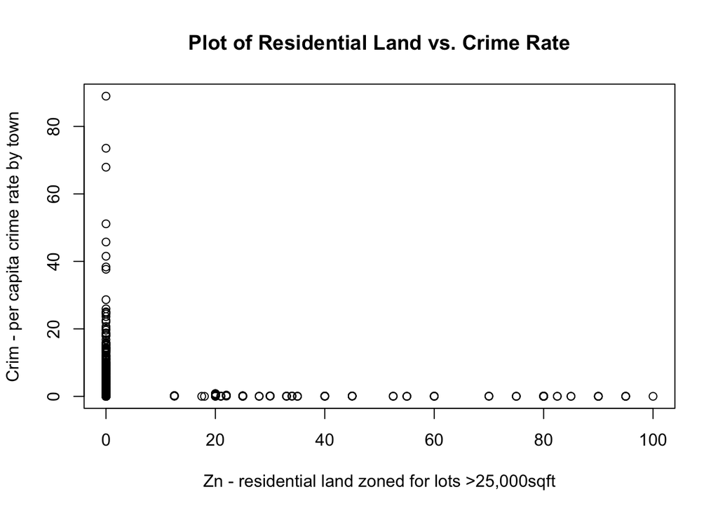

```r
plot(Boston$zn,Boston$crim,xlab="Zn - residential land zoned for lots >25,000sqft",ylab="Crim - per capita crime rate by town",main="Plot of Residential Land vs. Crime Rate")
```

```r
cov(Boston$zn, Boston$crim)
```

```
## [1] -40.21596
```

```r
cor(Boston$zn,Boston$crim)
```

```
## [1] -0.2004692
```

e.g. scatter plot of average number of rooms per dwelling (x) vs. crime rate (y)  
Findings: number of rooms and crime rate are not related. (No obvious visual relationship and low correlation)

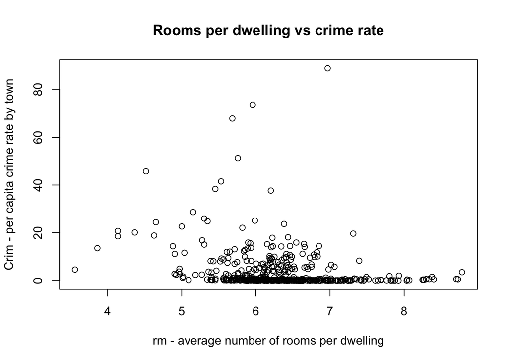

```r
plot(Boston$rm,Boston$crim, xlab="rm - average number of rooms per dwelling",ylab="Crim - per capita crime rate by town", main="Rooms per dwelling vs crime rate")
```

```r
cov(Boston$rm,Boston$crim)
```

```
## [1] -1.325038
```

```r
cor(Boston$rm,Boston$crim)
```

```
## [1] -0.2192467
```

e.g. scatter plot of the proportion of non-retail business acres per town vs. whether or not the town bounds the river. Hypothesis is that there is less industry if the town bounds the river i.e. that these variables are connected. Dummary variable is 1 if the tract bounds the river, 0 otherwise  
Findings: There seems to be no relationship between the level of industry and the location by the river - this is borne out by a very weak correlation between the two variables.

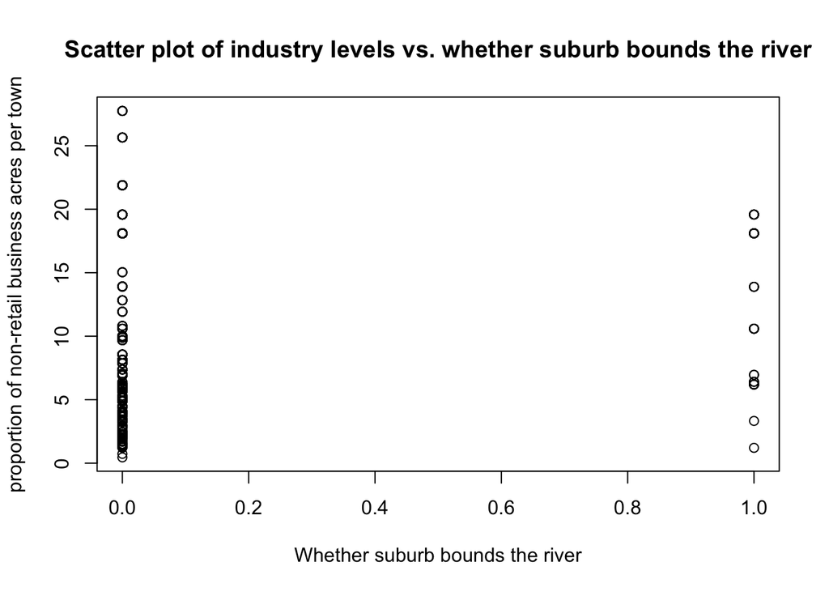

```r
plot(Boston$chas,Boston$indus,xlab = "Whether suburb bounds the river", ylab="proportion of non-retail business acres per town",main="Scatter plot of industry levels vs. whether suburb bounds the river")
```

```r
cov(Boston$chas, Boston$indus)
```

```
## [1] 0.1096688
```

```r
cor(Boston$chas, Boston$indus)
```

```
## [1] 0.06293803
```

e.g. scatter plot of average number of rooms per dwelling and proportion of owner-occupied units built prior to 1940. Hypothesis is that the average number of rooms per dwelling is determined by age.  
Findings: very low correlation, number of rooms per dwelling not determined by age

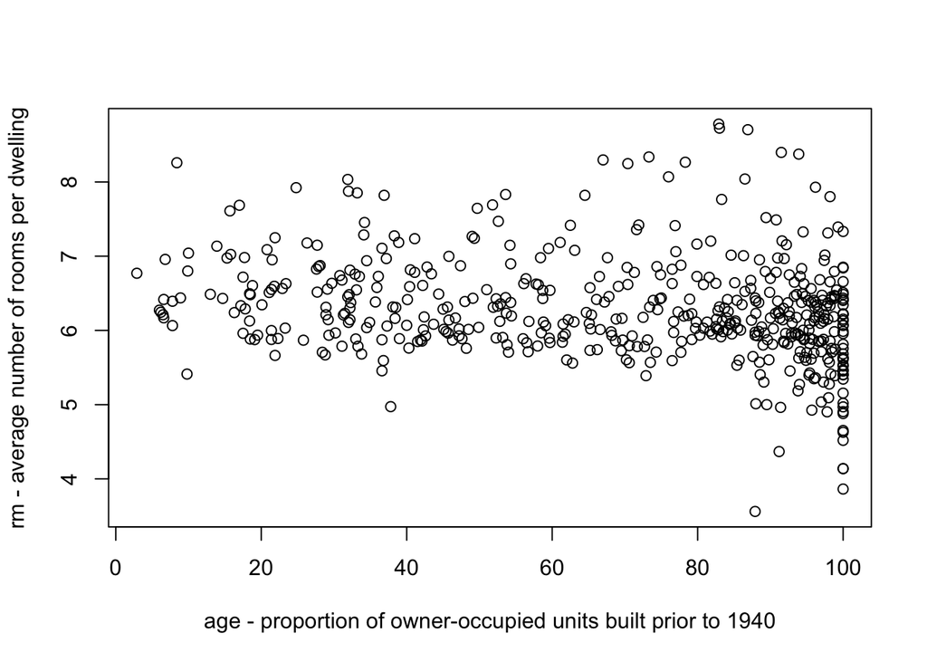

```r
plot(Boston$age,Boston$rm,xlab="age - proportion of owner-occupied units built prior to 1940",ylab="rm - average number of rooms per dwelling")
```

```r
cov(Boston$age,Boston$rm)
```

```
## [1] -4.751929
```

```r
cor(Boston$age,Boston$rm)
```

```
## [1] -0.2402649
```

The following function produces a scatterplot matrix of all the different variables:

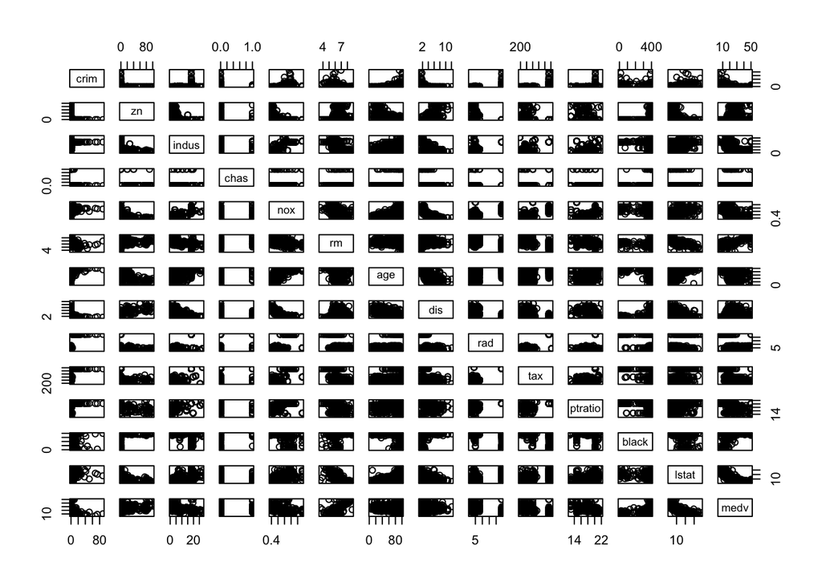

```r
pairs(Boston)
```

##### (c) Are any of the predictors associated with the per capita crime rate?

Next I investigate the relationship between crime rate and different predictors.

The correlation between the crime rate and zn is:

```r
cor(Boston$crim,Boston$zn)
```

```
## [1] -0.2004692
```

The correlation between the crime rate and indus is:

```r
cor(Boston$crim,Boston$indus)
```

```
## [1] 0.4065834
```

The correlation between the crime rate and chas is:

```r
cor(Boston$crim,Boston$chas)
```

```
## [1] -0.05589158
```

The correlation between the crime rate and nox is:

```r
cor(Boston$crim,Boston$nox)
```

```
## [1] 0.4209717
```

The correlation between the crime rate and rm is:

```r
cor(Boston$crim,Boston$rm)
```

```
## [1] -0.2192467
```

The correlation between the crime rate and age is:

```r
cor(Boston$crim,Boston$age)
```

```
## [1] 0.3527343
```

The correlation between the crime rate and dis is:

```r
cor(Boston$crim,Boston$dis)
```

```
## [1] -0.3796701
```

```r
cor(Boston$crim,Boston$rad)
```

```
## [1] 0.6255051
```

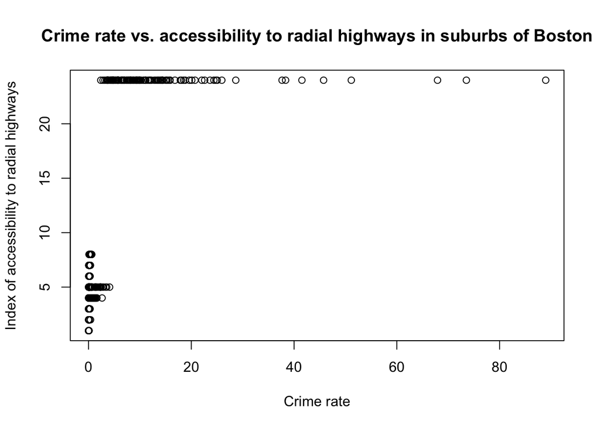

```r
plot(Boston$crim,Boston$rad,xlab="Crime rate",ylab="Index of accessibility to radial highways",main="Crime rate vs. accessibility to radial highways in suburbs of Boston")
```

The correlation between the crime rate and tax is shown below.  
Hypothesis for the relationship between crime rate and tax:  
Crime rates are higher in more affluent areas (this is actually the opposite of what I would expect).

```r
cor(Boston$crim,Boston$tax)
```

```
## [1] 0.5827643
```

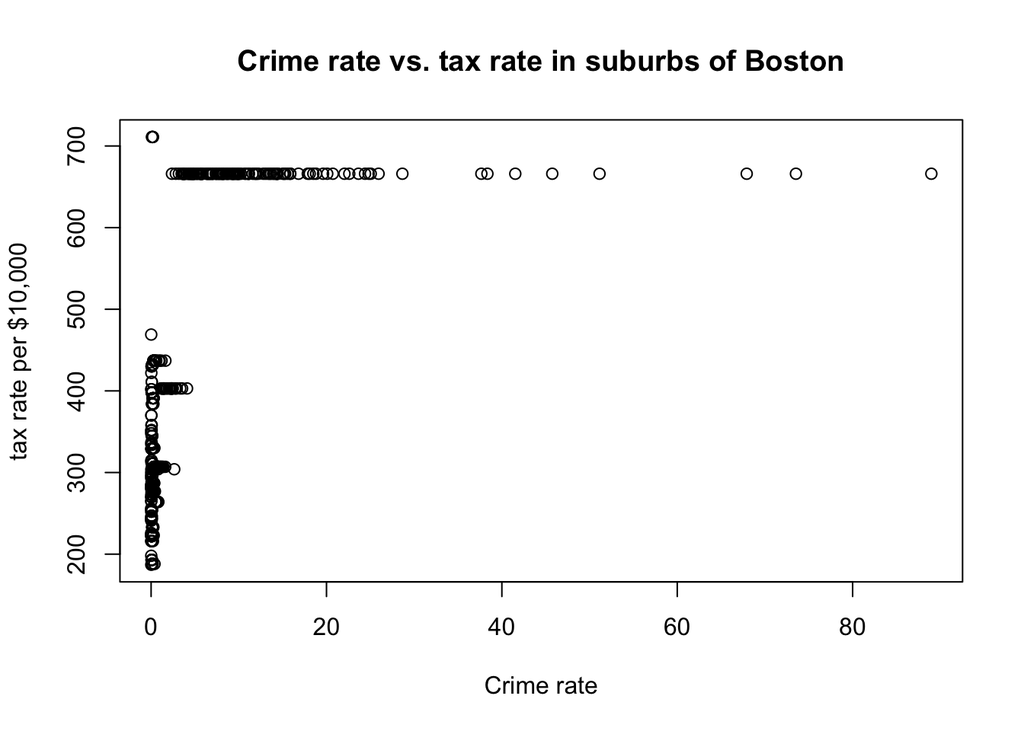

```r
plot(Boston$crim,Boston$tax, xlab="Crime rate", ylab="tax rate per $10,000",main="Crime rate vs. tax rate in suburbs of Boston")
```

The correlation between the crime rate and ptratio is:

```r
cor(Boston$crim,Boston$ptratio)
```

```
## [1] 0.2899456
```

The correlation between the crime rate and predictor ‘black’ is:

```r
cor(Boston$crim,Boston$black)
```

```
## [1] -0.3850639
```

The correlation between the crime rate and lstat is:

```r
cor(Boston$crim,Boston$lstat)
```

```
## [1] 0.4556215
```

The correlation between the crime rate and medv is:

```r
cor(Boston$crim,Boston$medv)
```

```
## [1] -0.3883046
```

There is a correlation between the crime rate and rad (index of acessibility to radial highways), and the crime rate and tax (tax rate per $10,000) - see possible reasons explained above. The correlation is indicated by a correlation value of > 0.5. There appears to be also some correlation between crime rate and predictors indus, nox and lstat.

##### (d) Are there any suburbs of Boston with particularly high crime rates? Tax rates? Pupil-teacher ratios? Comment on the range of each predictor.

Comment on the range of the per capita crime rate:  
The median crime rate per capita is 0.26 and the 3rd quartile is 3.68, very close to the mean of 3.61. This means that a small number of outliers is skewing the data, as shown in the plot. Looking at only the suburbs in which the crime rate is > 20 shows that there are 18 suburbs with the crime rate greater than this value. Running the script below shows the suburbs with particularly high crime rates.

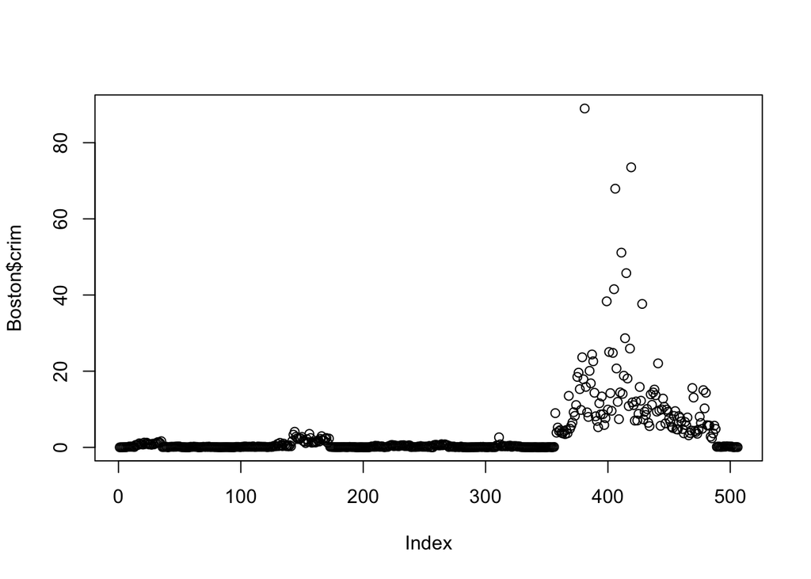

```r
plot(Boston$crim)
```

```r
table(sort(Boston$crim))
```

```
##
## 0.00632 0.00906 0.01096 0.01301 0.01311  0.0136 0.01381 0.01432 0.01439
##       1       1       1       1       1       1       1       1       1
## 0.01501 0.01538 0.01709 0.01778  0.0187 0.01951 0.01965 0.02009 0.02055
##       2       1       1       1       1       1       1       1       1
## 0.02177 0.02187 0.02498 0.02543 0.02729 0.02731 0.02763 0.02875 0.02899
##       1       1       1       1       1       1       1       1       1
## 0.02985 0.03041 0.03049 0.03113  0.0315 0.03237 0.03306 0.03359 0.03427
##       1       1       1       1       1       1       1       1       1
## 0.03445 0.03466 0.03502  0.0351 0.03537 0.03548 0.03551 0.03578 0.03584
##       1       1       1       1       1       1       1       1       1
## 0.03615 0.03659 0.03705 0.03738 0.03768 0.03871 0.03932 0.03961 0.04011
##       1       1       1       1       1       1       1       1       1
## 0.04113 0.04203 0.04294 0.04297 0.04301 0.04337 0.04379 0.04417 0.04462
##       1       1       1       1       1       1       1       1       1
## 0.04527 0.04544  0.0456  0.0459 0.04666 0.04684 0.04741 0.04819 0.04932
##       1       1       1       1       1       1       1       1       1
## 0.04981 0.05023 0.05059 0.05083 0.05188 0.05302  0.0536 0.05372 0.05425
##       1       1       1       1       1       1       1       1       1
## 0.05479 0.05497 0.05515 0.05561 0.05602 0.05644 0.05646  0.0566 0.05735
##       1       1       1       1       1       1       1       1       1
##  0.0578 0.05789 0.06047 0.06076 0.06127 0.06129 0.06151 0.06162 0.06211
##       1       1       1       1       1       1       1       1       1
## 0.06263 0.06417 0.06466 0.06588 0.06617 0.06642 0.06664 0.06724  0.0686
##       1       1       1       1       1       1       1       1       1
## 0.06888 0.06899 0.06905 0.06911 0.07013 0.07022 0.07151 0.07165 0.07244
##       1       1       1       1       1       1       1       1       1
## 0.07503 0.07875 0.07886 0.07896  0.0795 0.07978 0.08014 0.08187 0.08199
##       1       1       1       1       1       1       1       1       1
## 0.08221 0.08244 0.08265 0.08308  0.0837 0.08387 0.08447 0.08664 0.08707
##       1       1       1       1       1       1       1       1       1
## 0.08826 0.08829 0.08873 0.09065 0.09068 0.09103 0.09164 0.09178 0.09252
##       1       1       1       1       1       1       1       1       1
## 0.09266 0.09299 0.09378 0.09512 0.09604 0.09744 0.09849     0.1 0.10008
##       1       1       1       1       1       1       1       1       1
## 0.10084 0.10153  0.1029 0.10328 0.10469 0.10574 0.10612 0.10659 0.10793
##       1       1       1       1       1       1       1       1       1
## 0.10959 0.11027 0.11069 0.11132 0.11329 0.11425 0.11432  0.1146 0.11504
##       1       1       1       1       1       1       1       1       1
## 0.11747 0.12083 0.12204 0.12269 0.12329 0.12579  0.1265 0.12744 0.12757
```

[output cut: 58 more lines]

```
##       1       1       1       1       1       1       1       1       1
## 9.32909 9.33889 9.39063 9.51363 9.59571 9.72418 9.82349 9.91655 9.92485
##       1       1       1       1       1       1       1       1       1
## 9.96654 10.0623  10.233 10.6718 10.8342 11.0874 11.1081 11.1604 11.5779
##       1       1       1       1       1       1       1       1       1
## 11.8123 11.9511 12.0482 12.2472 12.8023 13.0751 13.3598 13.5222 13.6781
##       1       1       1       1       1       1       1       1       1
## 13.9134 14.0507 14.2362 14.3337 14.4208 14.4383 15.0234 15.1772  15.288
##       1       1       1       2       1       1       1       1       1
## 15.5757 15.8603 15.8744 16.8118 17.8667 18.0846 18.4982  18.811 19.6091
##       1       1       1       1       1       1       1       1       1
## 20.0849 20.7162 22.0511 22.5971 23.6482 24.3938 24.8017 25.0461 25.9406
##       1       1       1       1       1       1       1       1       1
## 28.6558 37.6619 38.3518 41.5292 45.7461 51.1358 67.9208 73.5341 88.9762
##       1       1       1       1       1       1       1       1       1
```

```r
summary(Boston$crim)
```

```
##     Min.  1st Qu.   Median     Mean  3rd Qu.     Max.
##  0.00632  0.08204  0.25650  3.61400  3.67700 88.98000
```

```r
newdata <- Boston[which(Boston$crim>20.0),]
newdata
```

```
##        crim zn indus chas   nox    rm   age    dis rad tax ptratio  black
## 379 23.6482  0  18.1    0 0.671 6.380  96.2 1.3861  24 666    20.2 396.90
## 381 88.9762  0  18.1    0 0.671 6.968  91.9 1.4165  24 666    20.2 396.90
## 385 20.0849  0  18.1    0 0.700 4.368  91.2 1.4395  24 666    20.2 285.83
## 387 24.3938  0  18.1    0 0.700 4.652 100.0 1.4672  24 666    20.2 396.90
## 388 22.5971  0  18.1    0 0.700 5.000  89.5 1.5184  24 666    20.2 396.90
## 399 38.3518  0  18.1    0 0.693 5.453 100.0 1.4896  24 666    20.2 396.90
## 401 25.0461  0  18.1    0 0.693 5.987 100.0 1.5888  24 666    20.2 396.90
## 404 24.8017  0  18.1    0 0.693 5.349  96.0 1.7028  24 666    20.2 396.90
## 405 41.5292  0  18.1    0 0.693 5.531  85.4 1.6074  24 666    20.2 329.46
## 406 67.9208  0  18.1    0 0.693 5.683 100.0 1.4254  24 666    20.2 384.97
## 407 20.7162  0  18.1    0 0.659 4.138 100.0 1.1781  24 666    20.2 370.22
## 411 51.1358  0  18.1    0 0.597 5.757 100.0 1.4130  24 666    20.2   2.60
## 414 28.6558  0  18.1    0 0.597 5.155 100.0 1.5894  24 666    20.2 210.97
## 415 45.7461  0  18.1    0 0.693 4.519 100.0 1.6582  24 666    20.2  88.27
```

[output cut: 23 more lines]

```r
sum(table(sort(newdata$crim)))
```

```
## [1] 18
```

Comment on the range of the tax rate (shorthand for ‘full-value property-tax rate per $10,000’):

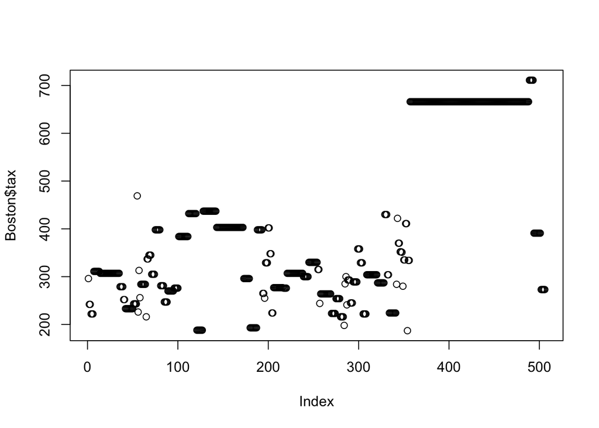

```r
plot(Boston$tax)
```

```r
table(sort(Boston$tax))
```

```
##
## 187 188 193 198 216 222 223 224 226 233 241 242 243 244 245 247 252 254
##   1   7   8   1   5   7   5  10   1   9   1   2   4   1   3   4   2   5
## 255 256 264 265 270 273 276 277 279 280 281 284 285 287 289 293 296 300
##   1   1  12   2   7   5   9  11   4   1   4   7   1   8   5   3   8   7
## 304 305 307 311 313 315 329 330 334 335 337 345 348 351 352 358 370 384
##  14   4  40   7   1   2   6  10   2   2   2   3   2   1   2   3   2  11
## 391 398 402 403 411 422 430 432 437 469 666 711
##   8  12   2  30   2   1   3   9  15   1 132   5
```

```r
summary(Boston$tax)
```

```
##    Min. 1st Qu.  Median    Mean 3rd Qu.    Max.
##   187.0   279.0   330.0   408.2   666.0   711.0
```

```r
newdata <- Boston[which(Boston$tax>=667.0),]
newdata
```

```
##        crim zn indus chas   nox    rm  age    dis rad tax ptratio  black
## 489 0.15086  0 27.74    0 0.609 5.454 92.7 1.8209   4 711    20.1 395.09
## 490 0.18337  0 27.74    0 0.609 5.414 98.3 1.7554   4 711    20.1 344.05
## 491 0.20746  0 27.74    0 0.609 5.093 98.0 1.8226   4 711    20.1 318.43
## 492 0.10574  0 27.74    0 0.609 5.983 98.8 1.8681   4 711    20.1 390.11
## 493 0.11132  0 27.74    0 0.609 5.983 83.5 2.1099   4 711    20.1 396.90
##     lstat medv
## 489 18.06 15.2
## 490 23.97  7.0
## 491 29.68  8.1
## 492 18.07 13.6
## 493 13.35 20.1
```

```r
sum(table(sort(newdata$tax)))
```

```
## [1] 5
```

```r
cor(Boston$crim,Boston$tax)
```

```
## [1] 0.5827643
```

Comments on the range of the pupil-teacher ratio:  
The minimum ratio is 12.6, the maximum is 22, and the median is 19.05, which is quite close to the maximum. There is a low correlation between the crime-rate and the pupil-teacher ratio in the suburbs of Boston.

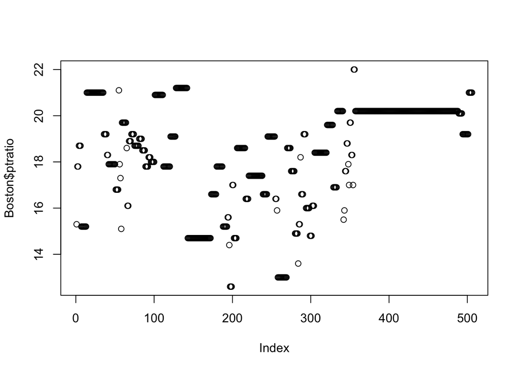

```r
plot(Boston$ptratio)
```

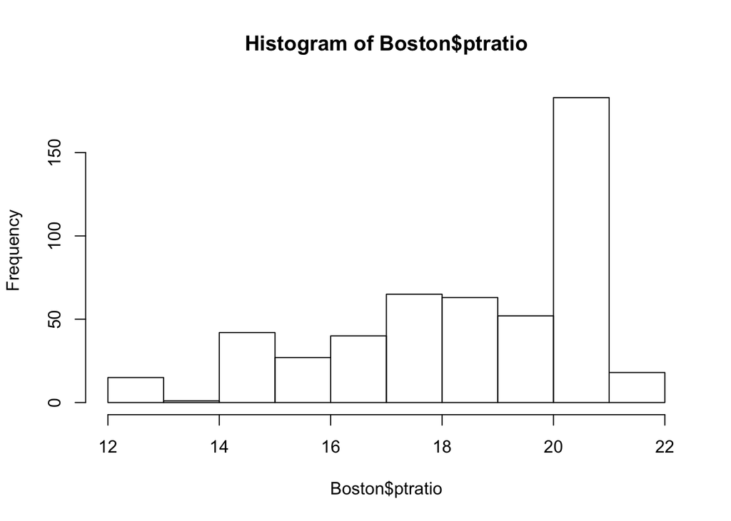

```r
hist(Boston$ptratio)
```

```r
table(sort(Boston$ptratio))
```

```
##
## 12.6   13 13.6 14.4 14.7 14.8 14.9 15.1 15.2 15.3 15.5 15.6 15.9   16 16.1
##    3   12    1    1   34    3    4    1   13    3    1    2    2    5    5
## 16.4 16.6 16.8 16.9   17 17.3 17.4 17.6 17.8 17.9   18 18.2 18.3 18.4 18.5
##    6   16    4    5    4    1   18    7   23   11    5    4    4   16    4
## 18.6 18.7 18.8 18.9   19 19.1 19.2 19.6 19.7 20.1 20.2 20.9   21 21.1 21.2
##   17    9    2    3    4   17   19    8    8    5  140   11   27    1   15
##   22
##    2
```

```r
summary(Boston$ptratio)
```

```
##    Min. 1st Qu.  Median    Mean 3rd Qu.    Max.
##   12.60   17.40   19.05   18.46   20.20   22.00
```

```r
newdata <- Boston[which(Boston$ptratio>=21.0),]
newdata
```

```
##        crim zn indus chas   nox    rm   age     dis rad tax ptratio  black
## 14  0.62976  0  8.14    0 0.538 5.949  61.8  4.7075   4 307    21.0 396.90
## 15  0.63796  0  8.14    0 0.538 6.096  84.5  4.4619   4 307    21.0 380.02
## 16  0.62739  0  8.14    0 0.538 5.834  56.5  4.4986   4 307    21.0 395.62
## 17  1.05393  0  8.14    0 0.538 5.935  29.3  4.4986   4 307    21.0 386.85
## 18  0.78420  0  8.14    0 0.538 5.990  81.7  4.2579   4 307    21.0 386.75
## 19  0.80271  0  8.14    0 0.538 5.456  36.6  3.7965   4 307    21.0 288.99
## 20  0.72580  0  8.14    0 0.538 5.727  69.5  3.7965   4 307    21.0 390.95
## 21  1.25179  0  8.14    0 0.538 5.570  98.1  3.7979   4 307    21.0 376.57
## 22  0.85204  0  8.14    0 0.538 5.965  89.2  4.0123   4 307    21.0 392.53
## 23  1.23247  0  8.14    0 0.538 6.142  91.7  3.9769   4 307    21.0 396.90
## 24  0.98843  0  8.14    0 0.538 5.813 100.0  4.0952   4 307    21.0 394.54
## 25  0.75026  0  8.14    0 0.538 5.924  94.1  4.3996   4 307    21.0 394.33
## 26  0.84054  0  8.14    0 0.538 5.599  85.7  4.4546   4 307    21.0 303.42
## 27  0.67191  0  8.14    0 0.538 5.813  90.3  4.6820   4 307    21.0 376.88
```

[output cut: 77 more lines]

```r
sum(table(sort(newdata$ptratio)))
```

```
## [1] 45
```

```r
cor(Boston$crim,Boston$ptratio)
```

```
## [1] 0.2899456
```

##### (e) How many suburbs bound the Charles river?

35 suburbs bound the Charles river.

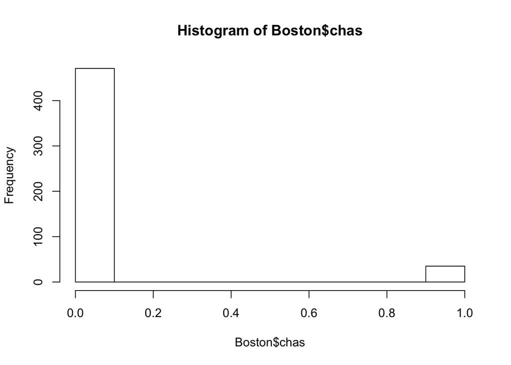

```r
hist(Boston$chas) #approx 20
```

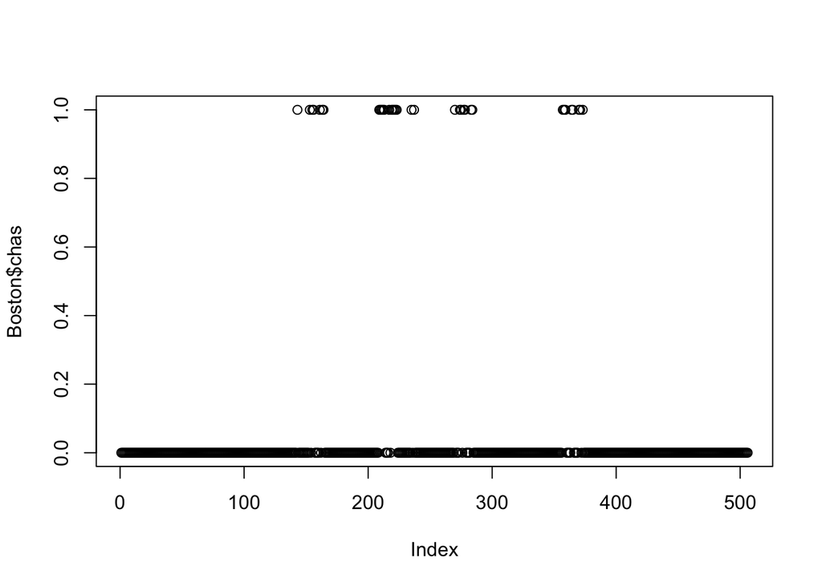

```r
plot(Boston$chas)
```

```r
table(sort(Boston$chas)) # 35 suburbs bound the Charles river
```

```
##
##   0   1
## 471  35
```

```r
newdata <- Boston[which(Boston$chas==1),]
table(newdata$chas) # there are 35 suburbs which bound the Charles river
```

```
##
##  1
## 35
```

##### (f) What is the median pupil-teacher ratio among the towns in this data set?

The median pupil-teacher ratio is 19.05

```r
summary(Boston$ptratio)
```

```
##    Min. 1st Qu.  Median    Mean 3rd Qu.    Max.
##   12.60   17.40   19.05   18.46   20.20   22.00
```

##### (g) Which suburb of Boston has lowest median value of owner occupied homes? What are the values of the other predictors for that suburb, and how do those values compare to the overall ranges for those predictors? Comment on your findings.

Suburbs 399 and 406 have the lowest median value of owner occupied homes.  
We can calculate this by defining a new data table, newdata, and including only the suburbs for which the variable medv is equal to the minimum. We can find the mininum using the summary function.The predictors are shown in the table for those suburbs.

```r
summary(Boston$medv)
```

```
##    Min. 1st Qu.  Median    Mean 3rd Qu.    Max.
##    5.00   17.02   21.20   22.53   25.00   50.00
```

```r
table(sort(Boston$medv))
```

```
##
##    5  5.6  6.3    7  7.2  7.4  7.5  8.1  8.3  8.4  8.5  8.7  8.8  9.5  9.6
##    2    1    1    2    3    1    1    1    2    2    2    1    2    1    1
##  9.7 10.2 10.4 10.5 10.8 10.9   11 11.3 11.5 11.7 11.8 11.9   12 12.1 12.3
##    1    3    2    2    1    2    1    1    1    2    2    2    1    1    1
## 12.5 12.6 12.7 12.8   13 13.1 13.2 13.3 13.4 13.5 13.6 13.8 13.9   14 14.1
##    1    1    3    1    1    4    1    3    4    2    2    5    2    1    3
## 14.2 14.3 14.4 14.5 14.6 14.8 14.9   15 15.1 15.2 15.3 15.4 15.6 15.7   16
##    1    2    2    3    2    1    3    3    1    3    1    2    5    1    1
## 16.1 16.2 16.3 16.4 16.5 16.6 16.7 16.8   17 17.1 17.2 17.3 17.4 17.5 17.6
##    3    2    1    1    2    2    2    2    1    3    3    1    3    3    1
## 17.7 17.8 17.9   18 18.1 18.2 18.3 18.4 18.5 18.6 18.7 18.8 18.9   19 19.1
##    1    5    1    1    1    3    2    3    4    2    3    2    4    2    4
## 19.2 19.3 19.4 19.5 19.6 19.7 19.8 19.9   20 20.1 20.2 20.3 20.4 20.5 20.6
##    2    5    6    4    5    2    3    4    5    5    2    4    4    3    6
## 20.7 20.8 20.9   21 21.1 21.2 21.4 21.5 21.6 21.7 21.8 21.9   22 22.1 22.2
##    2    3    2    3    2    5    5    2    2    7    2    3    7    1    5
## 22.3 22.4 22.5 22.6 22.7 22.8 22.9   23 23.1 23.2 23.3 23.4 23.5 23.6 23.7
##    2    2    3    5    2    4    4    4    7    4    4    2    1    2    4
## 23.8 23.9   24 24.1 24.2 24.3 24.4 24.5 24.6 24.7 24.8   25 25.1 25.2 25.3
##    4    5    2    3    1    3    4    3    2    3    4    8    1    1    1
## 26.2 26.4 26.5 26.6 26.7   27 27.1 27.5 27.9   28 28.1 28.2 28.4 28.5 28.6
##    1    2    1    3    1    1    2    4    2    1    1    1    2    1    1
## 28.7   29 29.1 29.4 29.6 29.8 29.9 30.1 30.3 30.5 30.7 30.8   31 31.1 31.2
##    3    2    2    1    2    2    1    3    1    1    1    1    1    1    1
## 31.5 31.6 31.7   32 32.2 32.4 32.5 32.7 32.9   33 33.1 33.2 33.3 33.4 33.8
##    2    2    1    2    1    1    1    1    1    1    2    2    1    2    1
## 34.6 34.7 34.9 35.1 35.2 35.4   36 36.1 36.2 36.4 36.5   37 37.2 37.3 37.6
##    1    1    3    1    1    2    1    1    2    1    1    1    1    1    1
## 37.9 38.7 39.8 41.3 41.7 42.3 42.8 43.1 43.5 43.8   44 44.8 45.4   46 46.7
##    1    1    1    1    1    1    1    1    1    1    1    1    1    1    1
## 48.3 48.5 48.8   50
##    1    1    1   16
```

```r
newdata <- Boston[which(Boston$medv==5.0),]
newdata
```

```
##        crim zn indus chas   nox    rm age    dis rad tax ptratio  black
## 399 38.3518  0  18.1    0 0.693 5.453 100 1.4896  24 666    20.2 396.90
## 406 67.9208  0  18.1    0 0.693 5.683 100 1.4254  24 666    20.2 384.97
##     lstat medv
## 399 30.59    5
## 406 22.98    5
```

```r
summary(Boston)
```

```
##       crim                zn             indus            chas
##  Min.   : 0.00632   Min.   :  0.00   Min.   : 0.46   Min.   :0.00000
##  1st Qu.: 0.08204   1st Qu.:  0.00   1st Qu.: 5.19   1st Qu.:0.00000
##  Median : 0.25651   Median :  0.00   Median : 9.69   Median :0.00000
##  Mean   : 3.61352   Mean   : 11.36   Mean   :11.14   Mean   :0.06917
##  3rd Qu.: 3.67708   3rd Qu.: 12.50   3rd Qu.:18.10   3rd Qu.:0.00000
##  Max.   :88.97620   Max.   :100.00   Max.   :27.74   Max.   :1.00000
##       nox               rm             age              dis
##  Min.   :0.3850   Min.   :3.561   Min.   :  2.90   Min.   : 1.130
##  1st Qu.:0.4490   1st Qu.:5.886   1st Qu.: 45.02   1st Qu.: 2.100
##  Median :0.5380   Median :6.208   Median : 77.50   Median : 3.207
##  Mean   :0.5547   Mean   :6.285   Mean   : 68.57   Mean   : 3.795
##  3rd Qu.:0.6240   3rd Qu.:6.623   3rd Qu.: 94.08   3rd Qu.: 5.188
##  Max.   :0.8710   Max.   :8.780   Max.   :100.00   Max.   :12.127
##       rad              tax           ptratio          black
##  Min.   : 1.000   Min.   :187.0   Min.   :12.60   Min.   :  0.32
##  1st Qu.: 4.000   1st Qu.:279.0   1st Qu.:17.40   1st Qu.:375.38
##  Median : 5.000   Median :330.0   Median :19.05   Median :391.44
##  Mean   : 9.549   Mean   :408.2   Mean   :18.46   Mean   :356.67
##  3rd Qu.:24.000   3rd Qu.:666.0   3rd Qu.:20.20   3rd Qu.:396.23
##  Max.   :24.000   Max.   :711.0   Max.   :22.00   Max.   :396.90
##      lstat            medv
##  Min.   : 1.73   Min.   : 5.00
##  1st Qu.: 6.95   1st Qu.:17.02
##  Median :11.36   Median :21.20
##  Mean   :12.65   Mean   :22.53
##  3rd Qu.:16.95   3rd Qu.:25.00
##  Max.   :37.97   Max.   :50.00
```

Comments on the findings for these suburbs, index 399 and 406:

Per capita crime rates (crim) are in the 4th quartile, near the maximum.  
The proportion of residential land zoned for lots over 25,000 sq.ft (zn) is zero, at the minimum for both suburbs.  
The proportion of non-retail business acres per town (indus) is 18.1, on the 3rd quartile boundary - so both suburbs are heavily industrialised.  
Neither district bounds the Charles river, indicated by the value of dummary variable (chas). The nitrogen oxides concentration (nox) is in the 4th quartile (0.693 and 0.693 vs 3rd quartile boundary 0.624), indicating relatively high levels of air pollution in these suburbs.  
The average number of rooms per dwelling (rm) is in 1st quartile, 5.45 and 5.68 vs 1st quartile boundary 5.886 The proportion of owner-occupied units built prior to 1940 is at the maximum, 100, again indicating relatively less wealthy suburbs of Boston. The weighted mean of distances to five Boston employment centres (dis) is in the first quartile, near the minimum at 1.49 and 1.43 (min is 1.13, 1st Quartile 2.10), showing that these suburbs are relatively close to employment centres.  
The index of accessibility to radial highways, rad is on the third quartile boundary/ maximum for both - indicating that both these suburbs are inner city areas.  
The full-value property tax rate per $10,000 is on the 3rd quartile boundary, 666 (near the maximum of 711.0).  
The pupil-teacher ratio is 20.2, on the 3rd quartile boundary, indicating there are a relatively high number of pupils for every teacher, an indicator of poverty.  
The black indicator (black) is 396.9 and 384.97, just below the maximum and 3rd quartile boundary, indicating there is a high proportion of black people in both suburbs.  
The lower status of the population, lstat is 30.59/ 22.98, is in the 4th quartile in both suburbs, and has a correlation of 0.46 with crime rate (I’m not sure whether a value at this level indicates whether there is a high level of correlation or not). The median value of owner-occupied homes in $1000s (medv) is 5, at the minimum. This indicates that in these suburbs with high crime rates, the value of owner-occupied homes is among the lowest in the city.

These indicators point to generally to lower quality housing, in industrial areas and the very highest crime rates, as well as high pupil-teacher ratios and other indicators which seem to demonstrate that disadvantaged socio-economic groups live in these two particular suburbs.

##### (h) In this data set, how many of the suburbs average more than seven rooms per dwelling? How many average more than eight rooms per dwelling?

```r
table(sort(Boston$rm))
```

```
##
## 3.561 3.863 4.138 4.368 4.519 4.628 4.652  4.88 4.903 4.906 4.926 4.963
##     1     1     2     1     1     1     1     1     1     1     1     1
##  4.97 4.973     5 5.012 5.019 5.036 5.093 5.155 5.186 5.272 5.277 5.304
##     1     1     1     1     1     1     1     1     1     1     1     2
## 5.344 5.349 5.362  5.39 5.399 5.403 5.404 5.412 5.414 5.427 5.453 5.454
##     1     1     1     2     1     1     2     1     1     1     1     1
## 5.456 5.468  5.52 5.531 5.536  5.56 5.565 5.569  5.57 5.572 5.593 5.594
##     1     1     1     1     1     1     1     1     1     1     1     1
## 5.597 5.599 5.602 5.604 5.605 5.608 5.613 5.617 5.627 5.628 5.631 5.637
##     1     1     1     1     1     1     1     1     1     1     1     1
## 5.648 5.663  5.67 5.682 5.683 5.693 5.701 5.705 5.706 5.707 5.708 5.709
##     1     1     1     1     1     1     1     1     1     1     1     1
## 5.713 5.727 5.731 5.741 5.747 5.757 5.759 5.762 5.782 5.783 5.786 5.787
##     3     1     1     1     1     2     1     1     1     1     1     1
##  5.79 5.794 5.803 5.807 5.813 5.818 5.822 5.834 5.836 5.837 5.841  5.85
##     1     1     1     1     2     1     1     1     1     1     1     1
## 5.851 5.852 5.854 5.856 5.857 5.859 5.868 5.869  5.87 5.871 5.872 5.874
##     1     1     2     2     1     1     1     1     1     1     1     1
## 5.875 5.876 5.877 5.878 5.879  5.88 5.884 5.885 5.887 5.888 5.889 5.891
##     2     1     1     1     1     1     1     1     1     2     1     1
## 5.895 5.896 5.898 5.905 5.913 5.914  5.92 5.924 5.926 5.927 5.928 5.933
##     1     1     1     1     1     1     1     1     2     1     1     1
## 5.935 5.936 5.942 5.949  5.95 5.951 5.952 5.957  5.96 5.961 5.963 5.965
##     2     2     1     1     1     1     1     1     1     2     1     1
## 5.966 5.968 5.972 5.976 5.981 5.983 5.985 5.986 5.987  5.99 5.998 6.003
##     2     1     1     1     1     2     1     1     1     1     1     1
## 6.004 6.006 6.009 6.012 6.014 6.015 6.019  6.02 6.021 6.023 6.027  6.03
##     2     1     2     1     1     1     1     1     1     1     1     2
## 6.031 6.037 6.041 6.047 6.051 6.059 6.064 6.065 6.066 6.069 6.072 6.081
##     1     1     1     1     1     1     1     1     1     1     1     1
## 6.083 6.086 6.092 6.095 6.096 6.101 6.103 6.108 6.112 6.113 6.114 6.115
##     1     1     1     1     2     1     1     2     1     1     1     1
##  6.12 6.121 6.122 6.127 6.129  6.13 6.137  6.14 6.142 6.144 6.145 6.151
##     1     1     2     3     1     1     1     1     1     2     1     1
## 6.152 6.153 6.162 6.163 6.164 6.167 6.169 6.172 6.174 6.176 6.182 6.185
##     2     1     2     1     1     3     1     1     1     1     1     2
## 6.193 6.195 6.202 6.208 6.209 6.211 6.212 6.216 6.219 6.223 6.226 6.229
##     2     1     1     1     2     2     1     1     1     1     1     3
##  6.23 6.232  6.24 6.242 6.245 6.249  6.25 6.251 6.254 6.266 6.273 6.279
```

[output cut: 22 more lines]

```
##     1     1     1     1     1     1     1     1     1     1     1     1
## 6.879 6.897 6.939 6.943 6.951 6.957 6.968 6.975 6.976  6.98 6.982 6.998
##     1     1     1     1     2     1     2     1     1     2     1     1
## 7.007 7.014 7.016 7.024 7.041 7.061 7.079 7.088 7.104 7.107 7.135 7.147
##     1     1     1     1     1     1     1     1     1     1     1     1
## 7.148 7.155 7.163 7.178 7.185 7.203 7.206 7.236 7.241 7.249 7.267 7.274
##     1     1     1     1     2     1     1     1     1     1     1     1
## 7.287 7.313 7.327 7.333 7.358 7.393 7.412 7.416  7.42 7.454  7.47 7.489
##     1     1     1     1     1     1     1     1     1     1     1     1
##  7.52  7.61 7.645 7.686 7.691 7.765 7.802  7.82 7.831 7.853 7.875 7.923
##     1     1     1     1     1     1     1     2     1     1     1     1
## 7.929 8.034  8.04 8.069 8.247 8.259 8.266 8.297 8.337 8.375 8.398 8.704
##     1     1     1     1     1     1     1     1     1     1     1     1
## 8.725  8.78
##     1     1
```

```r
newdata <- Boston[which(Boston$rm>=7.0),]
sum(table(sort(newdata$rm))) # there are 64 suburbs which average more than 7 rooms per dwelling
```

```
## [1] 64
```

```r
newdata <- Boston[which(Boston$rm>8.0),]
sum(table(sort(newdata$rm))) # there are 13 suburbs which average more than 8 rooms per dwelling
```

```
## [1] 13
```

```r
newdata
```

```
##        crim zn indus chas    nox    rm  age    dis rad tax ptratio  black
## 98  0.12083  0  2.89    0 0.4450 8.069 76.0 3.4952   2 276    18.0 396.90
## 164 1.51902  0 19.58    1 0.6050 8.375 93.9 2.1620   5 403    14.7 388.45
## 205 0.02009 95  2.68    0 0.4161 8.034 31.9 5.1180   4 224    14.7 390.55
## 225 0.31533  0  6.20    0 0.5040 8.266 78.3 2.8944   8 307    17.4 385.05
## 226 0.52693  0  6.20    0 0.5040 8.725 83.0 2.8944   8 307    17.4 382.00
## 227 0.38214  0  6.20    0 0.5040 8.040 86.5 3.2157   8 307    17.4 387.38
## 233 0.57529  0  6.20    0 0.5070 8.337 73.3 3.8384   8 307    17.4 385.91
## 234 0.33147  0  6.20    0 0.5070 8.247 70.4 3.6519   8 307    17.4 378.95
## 254 0.36894 22  5.86    0 0.4310 8.259  8.4 8.9067   7 330    19.1 396.90
## 258 0.61154 20  3.97    0 0.6470 8.704 86.9 1.8010   5 264    13.0 389.70
## 263 0.52014 20  3.97    0 0.6470 8.398 91.5 2.2885   5 264    13.0 386.86
## 268 0.57834 20  3.97    0 0.5750 8.297 67.0 2.4216   5 264    13.0 384.54
## 365 3.47428  0 18.10    1 0.7180 8.780 82.9 1.9047  24 666    20.2 354.55
##     lstat medv
## 98   4.21 38.7
## 164  3.32 50.0
## 205  2.88 50.0
## 225  4.14 44.8
## 226  4.63 50.0
## 227  3.13 37.6
## 233  2.47 41.7
## 234  3.95 48.3
## 254  3.54 42.8
## 258  5.12 50.0
## 263  5.91 48.8
## 268  7.44 50.0
## 365  5.29 21.9
```

```r
cor(newdata$rm,newdata$crim)
```

```
## [1] 0.6229495
```

```r
cor(newdata$rm,newdata$zn)
```

```
## [1] -0.312557
```

```r
cor(newdata$rm,newdata$indus)
```

```
## [1] 0.4159495
```

```r
cor(newdata$rm,newdata$chas)
```

```
## [1] 0.4044247
```

```r
cor(newdata$rm,newdata$nox)
```

```
## [1] 0.7167705
```

```r
cor(newdata$rm,newdata$age)
```

```
## [1] 0.3812105
```

```r
cor(newdata$rm,newdata$dis)
```

```
## [1] -0.4283683
```

```r
cor(newdata$rm,newdata$rad)
```

```
## [1] 0.5466241
```

```r
cor(newdata$rm,newdata$tax)
```

```
## [1] 0.522883
```

```r
cor(newdata$rm,newdata$ptratio)
```

```
## [1] 0.01528151
```

```r
cor(newdata$rm,newdata$black)
```

```
## [1] -0.5878303
```

```r
cor(newdata$rm,newdata$lstat)
```

```
## [1] 0.4117927
```

```r
cor(newdata$rm,newdata$medv)
```

```
## [1] -0.158056
```

Commentary on the suburbs that average more than eight rooms per dwelling:  
There is a strong positive correlation between the number of rooms and:  
the crime rate,the nitrogen oxide content, the index of access to radial highways, the tax rate.  
There is a strong negative correlation between the number of rooms and the black indicator - i.e. you are much more likely to be non-black by ethnic origin if you live in a house with more than 8 rooms per dwelling.

```r
rm(list=ls()) # removes all data
```

## Q3 regression analysis

##### (a) Using the rnorm() function, create a vector, x, containing 100 observations drawn from a N (0, 1) distribution, i.e., a normal distribution with mean 0 and variance 1 (sd = sqrt var = 1). This represents a feature, X.

```r
set.seed(1)
x=rnorm(100,mean=0,sd=1)
```

##### (b) Using the rnorm() function, create a vector, eps, containing 100 observations drawn from a N (0, 0. 25) distribution i.e. a normal distribution with mean 0 and variance 0.25.

```r
eps=rnorm(100,mean=0,sd=sqrt(0.25))
```

##### (c) Using X and EPS generate vector Y according to the model Y = -1 + 0.5*X + eps. What is the length of vector Y? What are the values of beta0 and beta1 in this linear model?

```r
y<-(-1)+0.5*x+eps
```

The vector y contains 100 observations Beta0 is -1, the intercept of the line with the x-axis when there is no error Beta1 is 0.5, the slope of the line

##### (d) Create a scatterplot displaying the relationship between X and Y. Comment on what you observe.

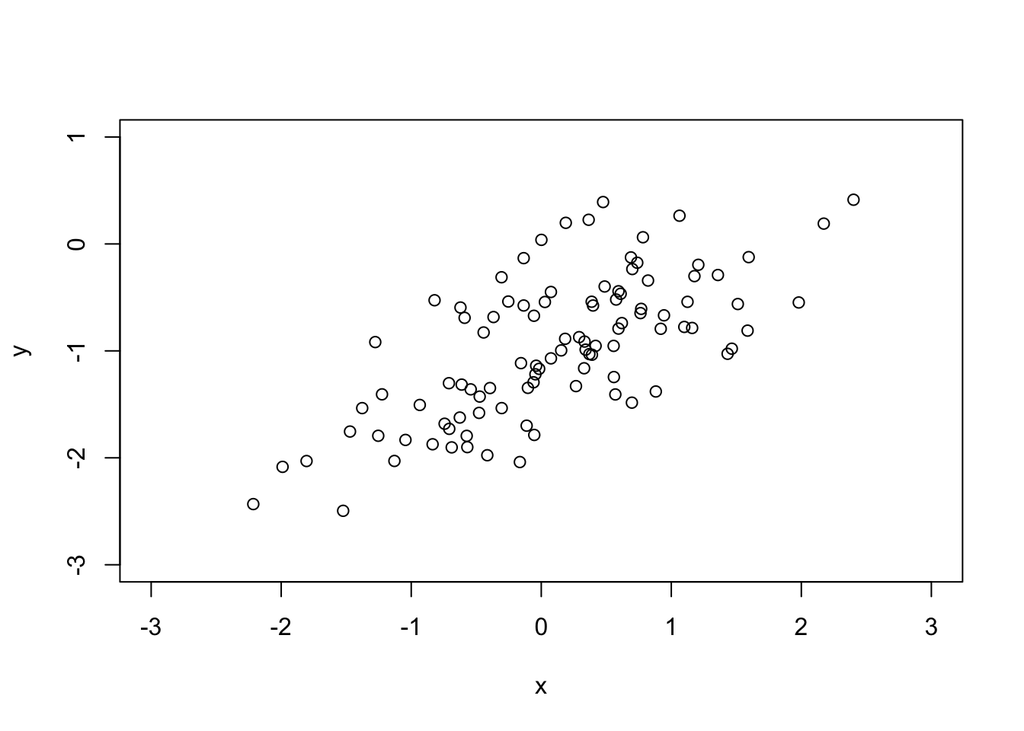

```r
plot(x,y,xlim=c(-3,3),ylim=c(-3,1))
```

Comment: The plot of x against y would be a straight line, where it not for the eps randomly generated error.

##### (e) Fit a least squares linear model to predict y using x. Comment on the model obtained. How do Beta0-hat and Beta1-hat compare to Beta0 and Beta1?

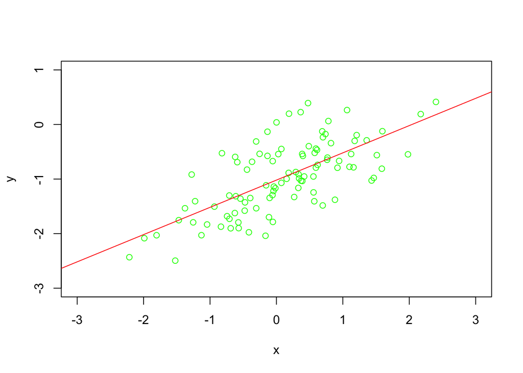

```r
plot(x,y,xlim=c(-3,3),ylim=c(-3,1),col="green")
Myregression = data.frame(x,y) # put vectors x and y into a data frame
lm.fit.Myregression=lm(y~x, data=Myregression) # call the variable lm.fit.Myregression

abline(lm.fit.Myregression, col="red") # fit the regression line
```

```r
summary(lm.fit.Myregression) # give a summary of the coefficients and standard error
```

```
##
## Call:
## lm(formula = y ~ x, data = Myregression)
##
## Residuals:
##      Min       1Q   Median       3Q      Max
## -0.93842 -0.30688 -0.06975  0.26970  1.17309
##
## Coefficients:
##             Estimate Std. Error t value Pr(>|t|)
## (Intercept) -1.01885    0.04849 -21.010  < 2e-16 ***
## x            0.49947    0.05386   9.273 4.58e-15 ***
## ---
## Signif. codes:  0 '***' 0.001 '**' 0.01 '*' 0.05 '.' 0.1 ' ' 1
##
## Residual standard error: 0.4814 on 98 degrees of freedom
## Multiple R-squared:  0.4674, Adjusted R-squared:  0.4619
## F-statistic: 85.99 on 1 and 98 DF,  p-value: 4.583e-15
```

```r
coefficients(lm.fit.Myregression) # gives the coefficients
```

```
## (Intercept)           x
##  -1.0188463   0.4994698
```

```r
beta0hat=lm.fit.Myregression$coefficients[1]
beta0hat #the value of beta0hat
```

```
## (Intercept)
##   -1.018846
```

```r
beta1hat=lm.fit.Myregression$coefficients[2]
beta1hat #the value of beta1hat
```

```
##         x
## 0.4994698
```

Commentary: the least squares linear line is shown in red on the graph.

Beta0hat is the intercept of the least squares regression line (shown in red) = -1.018846  
Beta1hat is the slope of the least squares regression line (shown in red) = 0.4994698

The values beta0hat and beta1hat are very close to the true values of Beta0 and Beta1 defined by the model, but slightly different due to the error introduced by the vector eps, which appropximates the irreducible error contained in the sample. The regression is an approximation which incorporates the irreducible error.

##### (f) Display the least squares line on the scatterplot obtained in (d). Draw the population regression line on the plot, in a different color. Use the legend() command to create an appropriate legend.

```r
summary(lm.fit.Myregression)
```

```
##
## Call:
## lm(formula = y ~ x, data = Myregression)
##
## Residuals:
##      Min       1Q   Median       3Q      Max
## -0.93842 -0.30688 -0.06975  0.26970  1.17309
##
## Coefficients:
##             Estimate Std. Error t value Pr(>|t|)
## (Intercept) -1.01885    0.04849 -21.010  < 2e-16 ***
## x            0.49947    0.05386   9.273 4.58e-15 ***
## ---
## Signif. codes:  0 '***' 0.001 '**' 0.01 '*' 0.05 '.' 0.1 ' ' 1
##
## Residual standard error: 0.4814 on 98 degrees of freedom
## Multiple R-squared:  0.4674, Adjusted R-squared:  0.4619
## F-statistic: 85.99 on 1 and 98 DF,  p-value: 4.583e-15
```

```r
beta0popln=-1+0.04849 # Population mean coefficient beta0popln is the coefficient plus the standard error, given by the summary function above
beta0popln # beta0 (intercept) for the population, rather than the sample
```

```
## [1] -0.95151
```

```r
beta1popln=0.5+0.05386 # Population mean coefficient beta1popln is the coefficent plus the standard error
beta1popln  #beta1 (slope of line) for the population, rather than the sample
```

```
## [1] 0.55386
```

Rmarkdown gives an error unless the plot is re-drawn, so I’m having to include the plot and regression calculation in the code fragment below. This is not necessary in the R file alone.

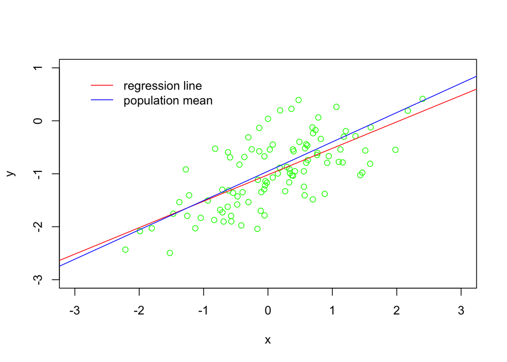

```r
plot(x,y,xlim=c(-3,3),ylim=c(-3,1),col="green")
Myregression = data.frame(x,y) # put vectors x and y into a data frame
lm.fit.Myregression=lm(y~x, data=Myregression) # call the variable lm.fit.Myregression
abline(lm.fit.Myregression, col="red") # fit the regression line
abline(beta0popln,beta1popln,untf=FALSE,col="blue") # fits the population mean on the graph
legend("topleft", inset=.05, c("regression line","population mean"),lty=c(1,1),lwd=c(1,1),col=c("red","blue"),bty="n",xjust=0,ncol=1)
```